# Introduction to extendedglmnetGroup18 Package

```
* Linear Regression/ Logistic regression
* Ridge Regression
* Lasso Regression
* Random Lasso Regression
```

Especially for random lasso, parameters $q_1$ and $q_2$, the numbers of predictors to select must be obtained by k-cross validation to perform the random lasso, which k value is assigned by `nfold`. The user can specify a subset of values of each $q_1$ and $q_2$ to do the cross validation using the function parameter `len`.

```r
library(extendedglmnetGroup18)
```

# Case 01 - Continuous Response

A user wants to predict whether Ozone concentration(ppb) using the following predictors based on 153 observations with 3 numeric predictors.

- `Temp`: numeric Maximum daily temperature (degrees F)
- `Solar.R`: numeric Solar radiation
- `Wind`: numeric average wind speed in miles per hour

## Data Preprocessing

```r
data("airquality")
dat=airquality[,c(1,2,3,4)]
colSums(is.na(dat)) # The number of NA values for each column
```

```
#>   Ozone Solar.R    Wind    Temp
#>      37       7       0       0
```

```r
dim(na.omit(dat)) # The number of rows and columns in the data
```

```
#> [1] 111   4
```

```r
y=dat$Ozone
X=dat[,-1]
```

The user creates a vector of $y$ response, and $X$ data frame of predictors for each column. Although there are missing values in the data, the user can input the data into the function since the function deletes the rows of missing values given the data. Therefore, the user will only be using 111 observations for fitting the model when there were originally 153 observations.

Now,the user will try to fit 4 different models.

- Multiple Linear Regression
- Ridge Regression
- Lasso Regression
- Random Lasso Regression

## Model Fitting and Performance

```r
set.seed(123)
linear=extended_glm(y,X,model='linear',prob=0.75)
```

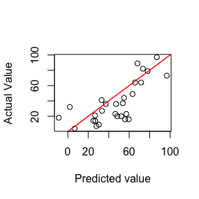

```r
set.seed(123)
ridge=extended_glm(y,X,model='ridge',prob=0.75)
```

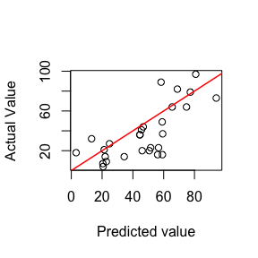

```r
set.seed(123)
lasso=extended_glm(y,X,model='lasso',prob=0.75)
```

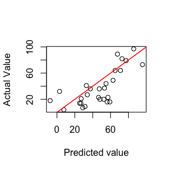

```r
set.seed(123)
random_lasso=extended_glm(y,X,model='random_lasso',prob=0.75,nfold=5)
```

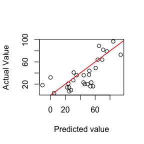

```r
result=as.vector(c(linear,ridge,lasso,random_lasso))
names(result)=paste0('RMSE','.',c('linear','ridge','lasso','random_lasso'));result
```

```
#>       RMSE.linear        RMSE.ridge        RMSE.lasso RMSE.random_lasso
#>          109.5367          107.0845          109.2271          103.9722
```

Based on the plotting and metrics, it seems to be that random lasso performed better based on the value 103.9721815.

# Case 02 - Continuous Response

This time the user tries to fit 4 different models with given $y$ response and $X$, a set of 3 numeric predictors where we use 100% training data set to fit the model. There is no missing value in the data, and the data size is 578 observations.

- Multiple Linear Regression
- Ridge Regression
- Lasso Regression
- Random Lasso Regression

```r
data("ChickWeight")
dat=ChickWeight
colSums(is.na(dat)) # No NA values
```

```
#> weight   Time  Chick   Diet
#>      0      0      0      0
```

```r
dim(na.omit(dat)) # The number of rows and columns in the data
```

```
#> [1] 578   4
```

```r
y=dat$weight
x1=dat$Time
x2=(dat$Time+rnorm(length(dat$Time)))^2
x3=2*dat$Time+rexp(length(dat$Time))
X=cbind(x1=x1,x2=x2,x3=x3)
```

Then they calculate the root mean square error on the data and see the model performance. For random lasso regression, it uses 10-fold cross validation to find parameters $q_1$, and $q_2$ for all possible values.

## Model Fitting and Performance

```r
set.seed(123)
linear=extended_glm(y,X,model='linear',prob=1)
```

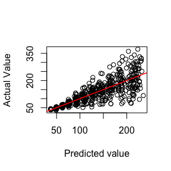

```r
set.seed(123)
ridge=extended_glm(y,X,model='ridge',prob=1)
```

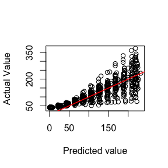

```r
set.seed(123)
lasso=extended_glm(y,X,model='lasso',prob=1)
```

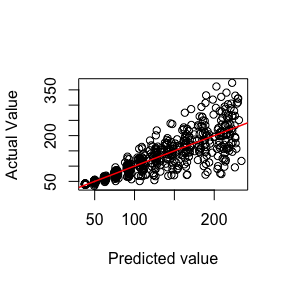

```r
set.seed(123)
random_lasso=extended_glm(y,X,model='random_lasso',prob=1,nfold=10)
```

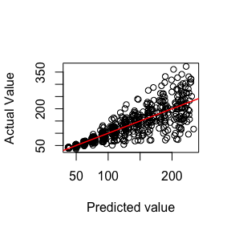

```r
result=as.vector(c(linear,ridge,lasso,random_lasso))
names(result)=paste0('RMSE','.',c('linear','ridge','lasso','random_lasso'));result
```

```
#>       RMSE.linear        RMSE.ridge        RMSE.lasso RMSE.random_lasso
#>          919.1688          989.0192          919.2491          919.3979
```

# Case 03 - Binary Response

- `weight`: numeric the female crab’ weight
- `width`: numeric the female crab’s carapace (shell) width
- `spine`: numeric the female crab’ spine condition

## Data Preprocessing

```r
Crabs <- read.table("http://www.stat.ufl.edu/~aa/cat/data/Crabs.dat", header=TRUE)
colSums(is.na(Crabs)) # No missing values
```

```
#>   crab    sat      y weight  width  color  spine
#>      0      0      0      0      0      0      0
```

```r
y=Crabs$y
X=Crabs[,c(4,5,7)]
X$spine=as.factor(X$spine)
```

The user tries to fit 4 different models.

- Logistic Regression
- Ridge Regression
- Lasso Regression
- Random Lasso Regression

It uses 80% of the data for training data and 20% for test data to calculate the root mean square error on that data and see the model performance. For random lasso regression, it uses 3-fold cross validation to find parameters $q_1$, and $q_2$ from 2 different values each.